# Reporte Caso Coho

Yasna Molina

2022-05-28

## **TÍTULO: *ESTUDIO DE CASO EN SALMON COHO DURANTE CICLO PRODUCTIVO 2021-2022***

## Autor: Yasna Molina Carvajal

## DESCRIPCIÓN DEL PROBLEMA

Se han realizado seguimientos en salmón coho desde piscicultura Playa Maqui. En un muestreo sanitario realizado el 17-03-2022, se detectaron trastornos hepáticos estructurales y funcionales, así como también hiperbilirrubinemia y presencia de células mononucleares a nivel hepático y cardíaco. Los análisis diagnósticos previos no han identificado la acción de algún agente infeccioso en particular, se sospecha la presentación subclínica de algún agente viral. Luego de esto, en reuniones de trabajo sotenidas con el cliente y evaluaciones de los peces en terreno, se plantea como problema principal la existencia de: Bajo score de grasa visceral en peces de la piscicultura previo traslado a centro Nieves, lo que promueve la generación de dos subpoblaciones en mar, una de peces de baja condición corporal (con tendencia al rezago) y otros de buena condición.

El objetivo de este estudio es evaluar las variables asociadas al problema, identificar causas probables y cuantificar la relevancia de cada una de ellas, obteniendo de esta manera información que permita mitigar y en lo posible prevenir la problematica durante las siguientes producciones.

Los principales factores a analizar son los siguientes:

- Exámenes de laboratorio en grupo de peces centro Playa Maqui
- Exámenes de laboratorio en grupo de peces centro Nieves
- Evaluación del score grasa visceral (SGV)

El total de observaciones son 272 siendo la variable respuesta los resultados sanitarios-productivos (SGR, FCR) obtenidos durante el ciclo de producción en mar durante el periodo de estudio.

```r
Tema = theme(axis.text.x= element_text(angle=90, size=7, color = "black"), axis.title.y = element_text(size=9), axis.text.y= element_text(size=8), legend.title=element_text(size=9),
legend.text=element_text (size=9))

Hemograma_PM<- read_excel("Resumen sangre Playa Maqui.xlsx")
PB_PM <- read_excel("Resumen sangre Playa Maqui.xlsx", sheet = "Hoja3")
Muestreo_PM <-read_excel("Muestreo peso 25.04.22 Playa Maqui.xlsx", na = "NA")
rm()
Hemograma_PM$Jaula<- as.factor(Hemograma_PM$Jaula)
Hemograma_PM$`N° CASO` <- as.factor(Hemograma_PM$`N° CASO`)
PB_PM$Jaula<- as.factor(PB_PM$Jaula)
PB_PM$`N° CASO` <- as.factor(PB_PM$`N° CASO`)
Rangos_referenciales_COHO <- read_excel("Rangos referenciales COHO.xlsx", sheet = "VGA coho smolt", na = "NA")
```

```r
Hemograma_Nieves<- read_excel("Resumen sangre Nieves.xlsx", na = "NA")
PB_Nieves <- read_excel ("Resumen sangre Nieves.xlsx", na = "NA", sheet="Hoja2")
Hemograma_Nieves$Condición<- as.factor(Hemograma_Nieves$Condición)
Hemograma_Nieves$`N° CASO` <- as.factor(Hemograma_Nieves$`N° CASO`)
PB_Nieves$Condición<- as.factor(PB_Nieves$Condición)
PB_Nieves$`N° CASO` <- as.factor(PB_Nieves$`N° CASO`)
rm()
```

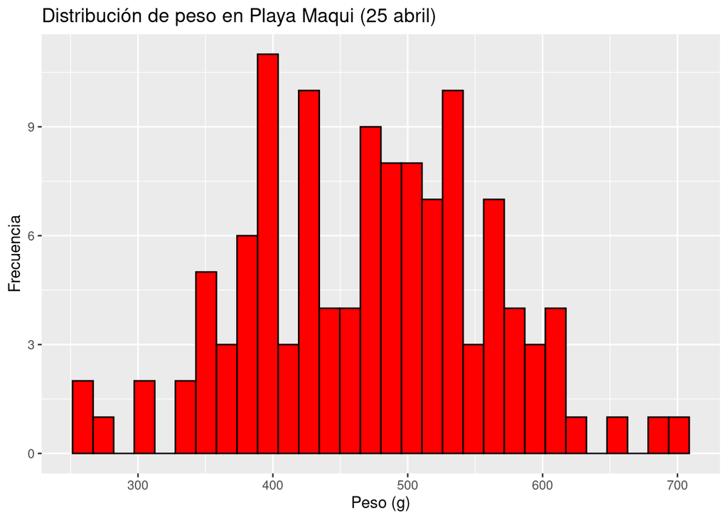

```r
Muestreo_PM$SGV<- as.factor(Muestreo_PM$SGV)
ggplot(Muestreo_PM, aes(x=W))+geom_histogram(bins = 30, color= "black", fill="red")+ labs(title= "Distribución de peso en Playa Maqui (25 abril)", x= "Peso (g)", y= "Frecuencia")
```

**Peso promedio** en muestreo del 25 de abril (previo traslado a centro Nieves)

```r
mean(Muestreo_PM$W)
```

```
## [1] 472.0333
```

**Factor de condición promedio** en muestreo del 25 de abril (previo traslado a centro Nieves)

```r
mean(Muestreo_PM$K)
```

```
## [1] 1.761067
```

**Peso promedio y factor de condición por jaula.**

```r
Muestreo_PM%>%group_by(Jaula)%>%summarise(`N° individuos`=n(), `Peso promedio`=mean(W), `Desviación estándar`=sd(W), `promedio k`=mean(K))
```

```
## # A tibble: 12 × 5
##    Jaula `N° individuos` `Peso promedio` `Desviación estándar` `promedio k`
##    <dbl>           <int>           <dbl>                 <dbl>        <dbl>
##  1   201              10            516.                  70.5         1.80
##  2   202              10            528.                  38.4         1.79
##  3   203              10            557.                  81.3         1.90
##  4   204              10            495.                  75.6         1.82
##  5   205              10            426.                  40.0         1.52
##  6   206              10            439.                  55.5         1.5
##  7   207              10            530.                 110.          1.86
##  8   208              10            374.                  64.1         1.77
##  9   209              10            490                   89.0         1.81
## 10   210              10            483.                  91.5         1.87
## 11   211              10            430.                  48.8         1.65
## 12   212              10            398.                  65.9         1.82
```

Los peces presentan buen factor de condición previo a su traslado, lo que se corresponde con las observaciones de campo, donde se observó robustez. Sin embargo al evaluar la anatomía interna de los peces, se genera gran alarma por la escasa cantidad de grasa visceral perivisceral encontrada, especialmente la que se ubica alrededor de los ciegos pilóricos (CP). Con el objetivo de cuantificar las observaciones, se elabora un score de grasa visceral (SGV) con factores del 1 al 5.

**1**: Grasa visceral no visible entre CP. **2**: Muy escasa grasa visceral entre CP, los que se observan completamente. **3**: Escasa grasa visceral entre CP, algunos de ellos cubiertos por grasa visceral. **4**. Moderada grasa visceral, lo que dificulta la observación de CP. **5**. Abundante grasa visceral, no se observan los CP.

**N° peces** según score de grasa visceral (**SGV**)

```r
summary(Muestreo_PM$SGV)
```

```
##    1    2    3    4 NA's
##    8   70   39    2    1
```

**SGV por jaula**

```r
table(Muestreo_PM$Jaula,Muestreo_PM$SGV)
```

```
##
##       1 2 3 4
##   201 0 3 7 0
##   202 0 5 5 0
##   203 2 5 3 0
##   204 2 5 2 0
##   205 0 5 3 2
##   206 0 5 5 0
##   207 0 8 2 0
##   208 3 5 2 0
##   209 0 8 2 0
##   210 0 6 4 0
##   211 0 6 4 0
##   212 1 9 0 0
```

**Relación SGV, K y Peso promedio**

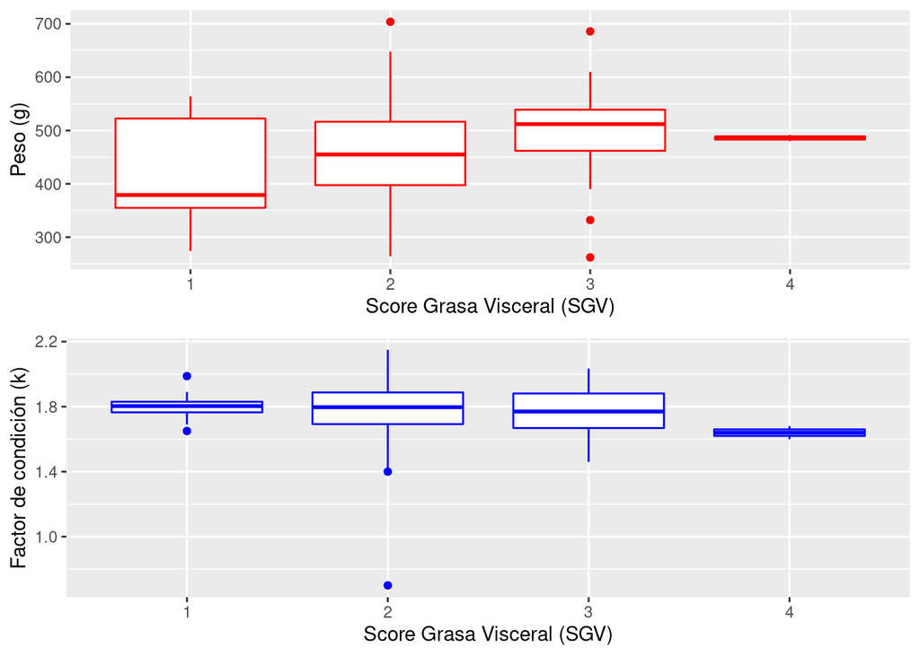

```r
Muestreo_PMaqui<- na.omit(Muestreo_PM)

plot_peso<-ggplot(Muestreo_PMaqui, aes(x=SGV,y=W))+geom_boxplot(color="red")+ labs (y= "Peso (g)", x= "Score Grasa Visceral (SGV)")

plot_k <-ggplot(Muestreo_PMaqui, aes(x=SGV,y=K))+geom_boxplot(color="blue")+ labs (x= "Score Grasa Visceral (SGV)", y= "Factor de condición (k)")

grid.arrange(plot_peso, plot_k)
```

No pareciera existir relación entre el factor de condición y el SGV, sin embargo entre peso y SGV si parece existir una relación.

## **Análisis de laboratorio**

Con el objetivo de identificar desviaciones fisiológicas en los peces de Playa Maqui, que permitan explicar los problemas de adapatación y rezago observados en el centro de mar (Nieves) y una posible relación con cantidad de grasa visceral, se realizaron análisis de laboratorio en distintos tiempos, a modo de seguimiento. Los resultados se presentan a continuación en formato de gráfico de cajas y bigotes.

```
## # A tibble: 1 × 4
##   Parámetro `Medida de concentración` MAX   MIN
##   <chr>     <chr>                     <chr> <chr>
## 1 VGA       %                         38    67
```

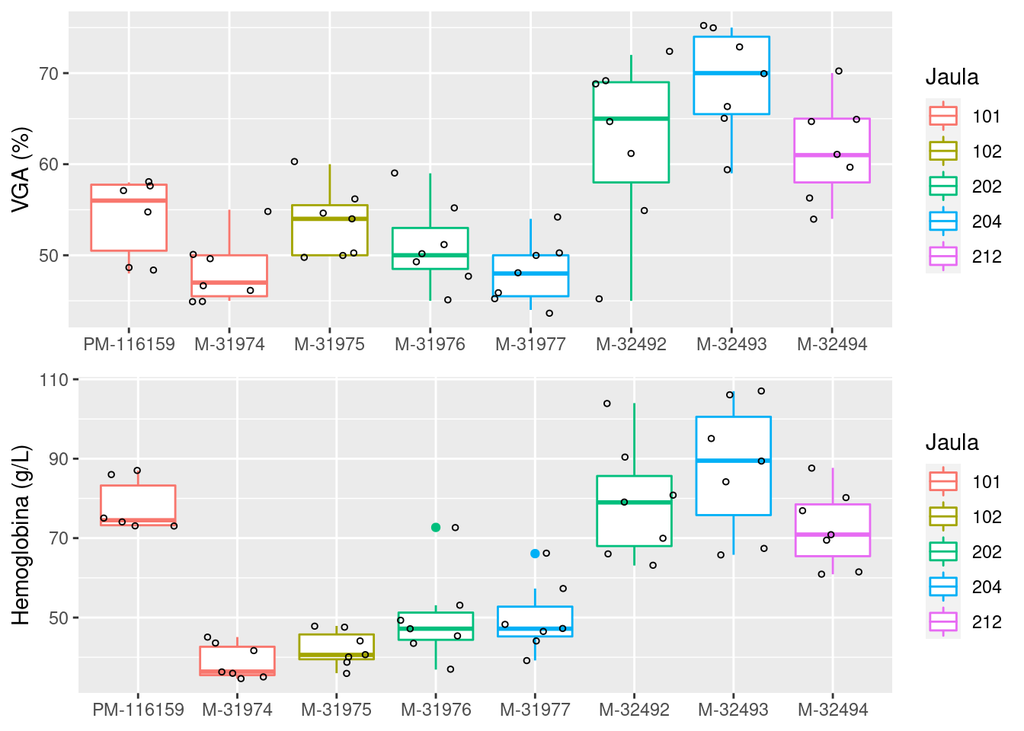

```r
VGA_plot <- ggplot(Hemograma_PM, aes(x= `N° CASO`, y=VGA))+geom_boxplot(aes(color=Jaula))+geom_jitter(size=1, shape=1)+ labs (x= NULL, y="VGA (%)")+ scale_x_discrete(limit=c("PM-116159", "M-31974", "M-31975", "M-31976", "M-31977", "M-32492", "M-32493", "M-32494"))

Hemoglobina_plot <- ggplot(Hemograma_PM, aes(x= `N° CASO`, y=Hemoglobina))+geom_boxplot(aes(color=Jaula))+geom_jitter(size=1, shape=1)+ labs (x= NULL, y="Hemoglobina (g/L)")+ scale_x_discrete(limit=c("PM-116159", "M-31974", "M-31975", "M-31976", "M-31977", "M-32492", "M-32493", "M-32494"))

VCM_plot <- ggplot(Hemograma_PM, aes(x= `N° CASO`, y=VCM))+geom_boxplot(aes(color=Jaula))+geom_jitter(size=1, shape=1)+ labs (x= NULL, y="VCM (fL))")+ scale_x_discrete(limit=c("PM-116159", "M-31974", "M-31975", "M-31976", "M-31977", "M-32492", "M-32493", "M-32494"))

CHCM_plot <- ggplot(Hemograma_PM, aes(x= `N° CASO`, y=CHCM))+geom_boxplot(aes(color=Jaula))+geom_jitter(size=1, shape=1)+ labs (x= NULL, y="CHCM (g/L))")+ scale_x_discrete(limit=c("PM-116159", "M-31974", "M-31975", "M-31976", "M-31977", "M-32492", "M-32493", "M-32494"))

grid.arrange(VGA_plot, Hemoglobina_plot)
```

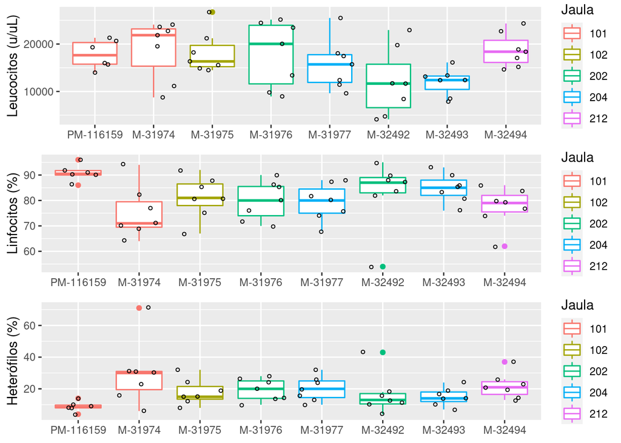

```r
LEUCOCITOS_plot <- ggplot(Hemograma_PM, aes(x= `N° CASO`, y=LEU))+geom_boxplot(aes(color=Jaula))+geom_jitter(size=1, shape=1)+ labs (x= NULL, y="Leucocitos (u/uL)")+ scale_x_discrete(limit=c("PM-116159", "M-31974", "M-31975", "M-31976", "M-31977", "M-32492", "M-32493", "M-32494"))

Linfocitos_plot <- ggplot(Hemograma_PM, aes(x= `N° CASO`, y=LIN))+geom_boxplot(aes(color=Jaula))+geom_jitter(size=1, shape=1)+ labs (x= NULL, y="Linfocitos (%)")+ scale_x_discrete(limit=c("PM-116159", "M-31974", "M-31975", "M-31976", "M-31977", "M-32492", "M-32493", "M-32494"))

Neutrofilos_plot <- ggplot(Hemograma_PM, aes(x= `N° CASO`, y=HET))+geom_boxplot(aes(color=Jaula))+geom_jitter(size=1, shape=1)+ labs (x= NULL, y="Heterófilos (%)")+ scale_x_discrete(limit=c("PM-116159", "M-31974", "M-31975", "M-31976", "M-31977", "M-32492", "M-32493", "M-32494"))

grid.arrange(LEUCOCITOS_plot, Linfocitos_plot, Neutrofilos_plot)
```

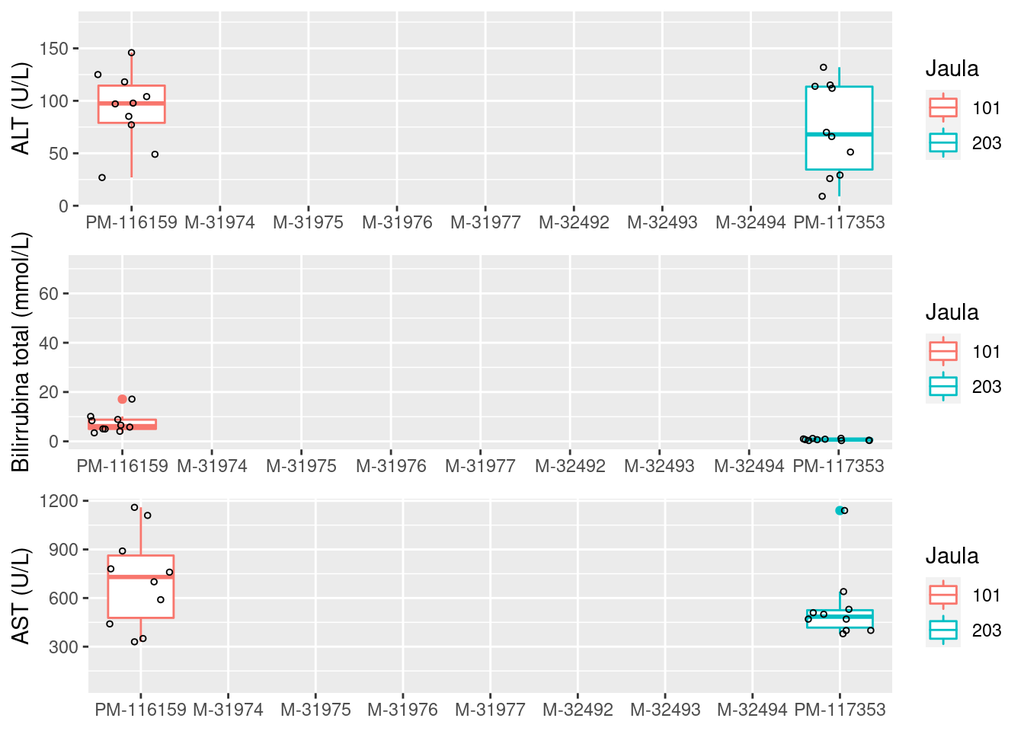

```r
ALT_plot <- ggplot(PB_PM, aes(x= `N° CASO`, y=ALT))+geom_boxplot(aes(color=Jaula))+geom_jitter(size=1, shape=1)+ labs (x= NULL, y="ALT (U/L)")+ scale_x_discrete(limit=c("PM-116159", "M-31974", "M-31975", "M-31976", "M-31977", "M-32492", "M-32493", "M-32494", "PM-117353"))

Bilirrubina_plot <- ggplot(PB_PM, aes(x= `N° CASO`, y=`BI total`))+geom_boxplot(aes(color=Jaula))+geom_jitter(size=1, shape=1)+ labs (x= NULL, y="Bilirrubina total (mmol/L)")+ scale_x_discrete(limit=c("PM-116159", "M-31974", "M-31975", "M-31976", "M-31977", "M-32492", "M-32493", "M-32494", "PM-117353"))

ALP_plot <- ggplot(PB_PM, aes(x= `N° CASO`, y=ALP))+geom_boxplot(aes(color=Jaula))+geom_jitter(size=1, shape=1)+ labs (x= NULL, y="ALP (U/L)")+ scale_x_discrete(limit=c("PM-116159", "M-31974", "M-31975", "M-31976", "M-31977", "M-32492", "M-32493", "M-32494", "PM-117353"))

AST_plot <- ggplot(PB_PM, aes(x= `N° CASO`, y=AST))+geom_boxplot(aes(color=Jaula))+geom_jitter(size=1, shape=1)+ labs (x= NULL, y="AST (U/L)")+ scale_x_discrete(limit=c("PM-116159", "M-31974", "M-31975", "M-31976", "M-31977", "M-32492", "M-32493", "M-32494", "PM-117353"))

CREA_plot <- ggplot(PB_PM, aes(x= `N° CASO`, y=CREA))+geom_boxplot(aes(color=Jaula))+geom_jitter(size=1, shape=1)+ labs (x= NULL, y="Creatinina (umol/L)")+ scale_x_discrete(limit=c("PM-116159", "M-31974", "M-31975", "M-31976", "M-31977", "M-32492", "M-32493", "M-32494", "PM-117353"))

UREA_plot <- ggplot(PB_PM, aes(x= `N° CASO`, y=UREA))+geom_boxplot(aes(color=Jaula))+geom_jitter(size=1, shape=1)+ labs (x= NULL, y="Urea (mmol/L)")+ scale_x_discrete(limit=c("PM-116159", "M-31974", "M-31975", "M-31976", "M-31977", "M-32492", "M-32493", "M-32494", "PM-117353"))

Amonio_plot <- ggplot(PB_PM, aes(x= `N° CASO`, y=AMM))+geom_boxplot(aes(color=Jaula))+geom_jitter(size=1, shape=1)+ labs (x= NULL, y="Amonio (mmol/L)")+ scale_x_discrete(limit=c("PM-116159", "M-31974", "M-31975", "M-31976", "M-31977", "M-32492", "M-32493", "M-32494", "PM-117353"))

CK_plot <- ggplot(PB_PM, aes(x= `N° CASO`, y=CK-total))+geom_boxplot(aes(color=Jaula))+geom_jitter(size=1, shape=1)+ labs (x= NULL, y="CK total (U/L)")+ scale_x_discrete(limit=c("PM-116159", "M-31974", "M-31975", "M-31976", "M-31977", "M-32492", "M-32493", "M-32494", "PM-117353"))

CK_plot <- ggplot(PB_PM, aes(x= `N° CASO`, y=CK-total))+geom_boxplot(aes(color=Jaula))+geom_jitter(size=1, shape=1)+ labs (x= NULL, y="CK total (U/L)")+ scale_x_discrete(limit=c("PM-116159", "M-31974", "M-31975", "M-31976", "M-31977", "M-32492", "M-32493", "M-32494", "PM-117353"))

LDH_plot <- ggplot(PB_PM, aes(x= `N° CASO`, y=LDH))+geom_boxplot(aes(color=Jaula))+geom_jitter(size=1, shape=1)+ labs (x= NULL, y="Lactato deshidrogenasa (U/L)")+ scale_x_discrete(limit=c("PM-116159", "M-31974", "M-31975", "M-31976", "M-31977", "M-32492", "M-32493", "M-32494", "PM-117353"))

Amilasa_plot <- ggplot(PB_PM, aes(x= `N° CASO`, y=Amilasa))+geom_boxplot(aes(color=Jaula))+geom_jitter(size=1, shape=1)+ labs (x= NULL, y="Amilasa (U/L)")+ scale_x_discrete(limit=c("PM-116159", "M-31974", "M-31975", "M-31976", "M-31977", "M-32492", "M-32493", "M-32494", "PM-117353"))

NA_plot <- ggplot(PB_PM, aes(x= `N° CASO`, y=`NA`))+geom_boxplot(aes(color=Jaula))+geom_jitter(size=1, shape=1)+ labs (x= NULL, y="Sodio (mmol/L)")+ scale_x_discrete(limit=c("PM-116159", "M-31974", "M-31975", "M-31976", "M-31977", "M-32492", "M-32493", "M-32494", "PM-117353"))

Cl_plot <- ggplot(PB_PM, aes(x= `N° CASO`, y=Cl))+geom_boxplot(aes(color=Jaula))+geom_jitter(size=1, shape=1)+ labs (x= NULL, y="Cloro (mmol/L)")+ scale_x_discrete(limit=c("PM-116159", "M-31974", "M-31975", "M-31976", "M-31977", "M-32492", "M-32493", "M-32494", "PM-117353"))


grid.arrange(ALT_plot, Bilirrubina_plot, AST_plot)
```

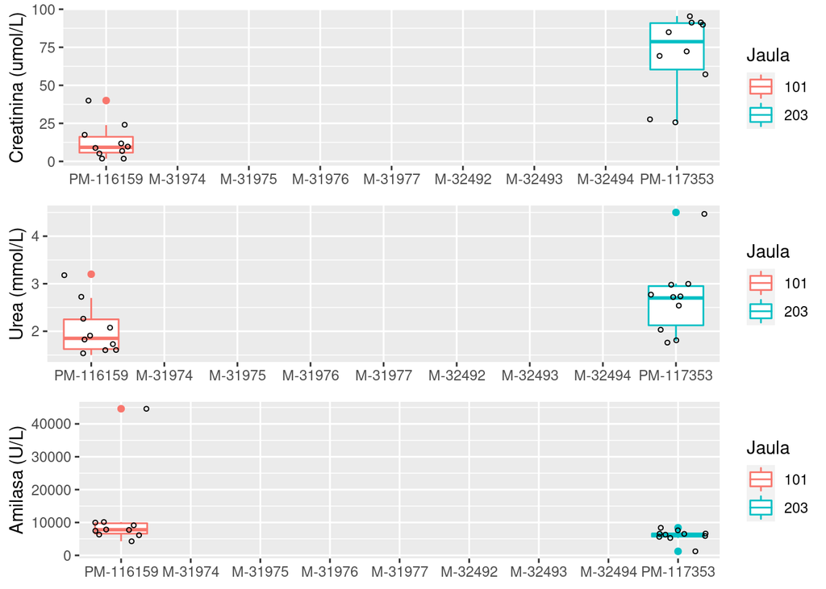

```r
grid.arrange (CREA_plot, UREA_plot, Amilasa_plot)
```

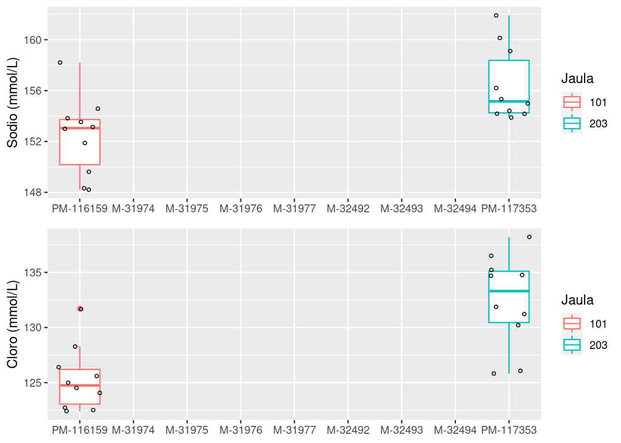

```r
grid.arrange(NA_plot, Cl_plot)
```